# Generalized Linear Models

```r
# The easiest way to get recipes is to install all of tidymodels:
# install.packages("tidymodels")
options(encoding = 'UTF-8')
#Loading all the necessary packages
if (!require("caret")) install.packages("caret")
if (!require("recipes")) install.packages("recipes")
if (!require("visreg")) install.packages("visreg")
if (!require("MASS")) install.packages("MASS")
if (!require("glmnet")) install.packages("glmnet")
if (!require("jtools")) install.packages("jtools")
if (!require("scales")) install.packages("scales")
if (!require("forcats")) install.packages("forcats")
if (!require("stringr")) install.packages("stringr")
if (!require("poissonreg")) install.packages("poissonreg")
require("caret")
require("recipes")
require("visreg")
require("MASS")
require("glmnet")
require("jtools")
require("scales")
require("forcats")
require("stringr")
require("arrow")
require("forcats")
require("yardstick")
require("parsnip")
require("workflows")
require("poissonreg")
require("rsample")
require("tune")
```

```r
require("yardstick")

options(repr.plot.width = 8, repr.plot.height = 6, repr.plot.res = 150);
```

We can also load the data (same as in the previous sessions).

```r
dataset = read_parquet(file = "../data/dataset.parquet")
```

## Data Preparation

For GLMs, we will need to prepare the data that we feed to the model. Indeed, we will have to provide the list of variables we wish to use and also supply the interactions terms. On top of that, we will *probably* need to bin some continuous variables into categorical ones. Let us re-take a look at some of the variables in the dataset.

An important preliminary step is always data preparation. In our simple dataset, we only have 10 variables. As a reminder, we have the following variables.

```r
str(dataset)
```

```
## tibble [410,864 × 10] (S3: tbl_df/tbl/data.frame)
##  $ PolicyID : Factor w/ 413169 levels "1","2","3","4",..: 1 2 3 4 5 6 7 8 9 10 ...
##  $ ClaimNb  : int [1:410864] 0 0 0 0 0 0 0 0 0 0 ...
##  $ Exposure : num [1:410864] 0.09 0.84 0.52 0.45 0.15 0.75 0.81 0.05 0.76 0.34 ...
##  $ Power    : Factor w/ 12 levels "d","e","f","g",..: 4 4 3 3 4 4 1 1 1 6 ...
##  $ CarAge   : int [1:410864] 0 0 2 2 0 0 1 0 9 0 ...
##  $ DriverAge: int [1:410864] 46 46 38 38 41 41 27 27 23 44 ...
##  $ Brand    : Factor w/ 7 levels "Fiat","Japanese (except Nissan) or Korean",..: 2 2 2 2 2 2 2 2 1 2 ...
##  $ Gas      : Factor w/ 2 levels "Diesel","Regular": 1 1 2 2 1 1 2 2 2 2 ...
##  $ Region   : Factor w/ 10 levels "Aquitaine","Basse-Normandie",..: 1 1 8 8 9 9 1 1 8 6 ...
##  $ Density  : int [1:410864] 76 76 3003 3003 60 60 695 695 7887 27000 ...
```

As we see, some variables are considered as integers (int) and others are considered as factors. For factor variable, an important feature is the **reference level**. R automatically assigns the **first category/value** encountered as reference level. This can often be suboptimal, and it is preferable to have as reference level the category with the most observation (or largest exposure).

### Brand

We can see the different levels of a factor variable with the levels function. The first level is the **reference level**.

```r
levels(dataset$Brand)
```

```
## [1] "Fiat"                               "Japanese (except Nissan) or Korean"
## [3] "Mercedes, Chrysler or BMW"          "Opel, General Motors or Ford"
## [5] "other"                              "Renault, Nissan or Citroen"
## [7] "Volkswagen, Audi, Skoda or Seat"
```

Using the function *fct_count* from package *forcats* we can easily compute the number of rows for each level of the factor variable.

```r
dataset$Brand %>% fct_count(sort=TRUE, prop=TRUE)
```

```
## # A tibble: 7 × 3
##   f                                       n      p
##   <fct>                               <int>  <dbl>
## 1 Renault, Nissan or Citroen         216684 0.527
## 2 Japanese (except Nissan) or Korean  79031 0.192
## 3 Opel, General Motors or Ford        37287 0.0908
## 4 Volkswagen, Audi, Skoda or Seat     32384 0.0788
## 5 Mercedes, Chrysler or BMW           19087 0.0465
## 6 Fiat                                16653 0.0405
## 7 other                                9738 0.0237
```

*Renault, Nissan or Citroen* appears to be the most populated level of variable ‘Brand’. This is why we will set this level as reference level, using the function **relevel**, or we can directly use the relevant function from the forcats package that will determine the most populated level and set that level as the reference level.

```r
# dataset$Brand = relevel(x = dataset$Brand, ref= "Renault, Nissan or Citroen")
# Easier with forcats

dataset$Brand = dataset$Brand %>% fct_infreq()
levels(dataset$Brand)
```

```
## [1] "Renault, Nissan or Citroen"         "Japanese (except Nissan) or Korean"
## [3] "Opel, General Motors or Ford"       "Volkswagen, Audi, Skoda or Seat"
## [5] "Mercedes, Chrysler or BMW"          "Fiat"
## [7] "other"
```

### Gas

```r
dataset$Gas %>% fct_count(sort=TRUE, prop=TRUE)
```

```
## # A tibble: 2 × 3
##   f            n     p
##   <fct>    <int> <dbl>
## 1 Regular 205565 0.500
## 2 Diesel  205299 0.500
```

We will set Regular as reference level.

```r
dataset$Gas = dataset$Gas %>% fct_infreq()
levels(dataset$Gas)
```

```
## [1] "Regular" "Diesel"
```

### Region

```r
dataset$Region %>% fct_count(sort=TRUE, prop=TRUE)
```

```
## # A tibble: 10 × 3
##    f                       n      p
##    <fct>               <int>  <dbl>
##  1 Centre             159426 0.388
##  2 Ile-de-France       69576 0.169
##  3 Bretagne            41986 0.102
##  4 Pays-de-la-Loire    38541 0.0938
##  5 Aquitaine           31211 0.0760
##  6 Nord-Pas-de-Calais  27111 0.0660
##  7 Poitou-Charentes    18900 0.0460
##  8 Basse-Normandie     10848 0.0264
##  9 Haute-Normandie      8726 0.0212
## 10 Limousin             4539 0.0110
```

We will set Center as reference level.

```r
dataset$Region = dataset$Region %>% fct_infreq()
levels(dataset$Region)
```

```
##  [1] "Centre"             "Ile-de-France"      "Bretagne"
##  [4] "Pays-de-la-Loire"   "Aquitaine"          "Nord-Pas-de-Calais"
##  [7] "Poitou-Charentes"   "Basse-Normandie"    "Haute-Normandie"
## [10] "Limousin"
```

### Power

Power is bit of a different factor variable. Indeed, there is some order between the levels (from lower power to higher power).

```r
dataset$Power %>% fct_count(sort=TRUE, prop=TRUE)
```

```
## # A tibble: 12 × 3
##    f         n       p
##    <fct> <int>   <dbl>
##  1 f     95432 0.232
##  2 g     90663 0.221
##  3 e     76784 0.187
##  4 d     67660 0.165
##  5 h     26558 0.0646
##  6 j     17978 0.0438
##  7 i     17398 0.0423
##  8 k      9270 0.0226
##  9 l      4593 0.0112
## 10 m      1758 0.00428
## 11 o      1494 0.00364
## 12 n      1276 0.00311
```

We will leave *d* as reference level, as it is highly populated and will allow us to keep it simple to interpret the regression coefficients (levels are ordered).

```r
dataset$Power = dataset$Power %>% fct_relevel(sort)
levels(dataset$Power)
```

```
##  [1] "d" "e" "f" "g" "h" "i" "j" "k" "l" "m" "n" "o"
```

## Model

We are going to model the claim frequencies using a GLM. We will only consider the categorical variables in this part, as we will see later that other tools are available to treat the continuous variables without having to discretize them.

Let us first split our dataset in two parts: a training set and a testing set (this step requires the caret package).

```r
set.seed(21)  # For reproducibility
in_training = createDataPartition(dataset$ClaimNb, times = 1, p = 0.8, list = FALSE)
training_set = dataset[in_training, ]
testing_set = dataset[-in_training, ]
```

### Intercept

The main function is called *glm*. Let us run the function on our training set. We will need to provide the offset to account for the different Exposures.

```r
m0 = glm(ClaimNb ~ offset(log(Exposure)),
         data = training_set,
         family = poisson())
summary(m0)
```

```
##
## Call:
## glm(formula = ClaimNb ~ offset(log(Exposure)), family = poisson(),
##     data = training_set)
##
## Coefficients:
##              Estimate Std. Error z value Pr(>|z|)
## (Intercept) -2.655615   0.008789  -302.1   <2e-16 ***
## ---
## Signif. codes:  0 '***' 0.001 '**' 0.01 '*' 0.05 '.' 0.1 ' ' 1
##
## (Dispersion parameter for poisson family taken to be 1)
##
##     Null deviance: 84299  on 328691  degrees of freedom
## Residual deviance: 84299  on 328691  degrees of freedom
## AIC: 109308
##
## Number of Fisher Scoring iterations: 6
```

By default, the link function is the log (see help file ?poisson).

In a GLM without any variables, the exponential of the intercept $\exp\beta_0$ corresponds to the average claim frequency.

Indeed, if we compare $\exp\beta_0$ with $\displaystyle\frac{\sum_i ClaimNB_i}{\sum_i Exposure_i}$, we obtain

```r
list(exp(m0$coef[1]), # m0$coef[1] is the Intercept
     with(training_set, sum(ClaimNb) / sum(Exposure)))
```

```
## [[1]]
## (Intercept)
##  0.07025564
##
## [[2]]
## [1] 0.07025564
```

### Include Variables

First, we will only consider the discrete variables, namely Power, Brand, Gas and Region.

Let us include all these variables (without interactions) in the model.

```r
m1 = glm(ClaimNb ~ offset(log(Exposure)) + Power + Gas + Brand + Region,
         data = training_set,
         family = poisson(link = log))
summary(m1)
```

```
##
## Call:
## glm(formula = ClaimNb ~ offset(log(Exposure)) + Power + Gas +
##     Brand + Region, family = poisson(link = log), data = training_set)
##
## Coefficients:
##                                         Estimate Std. Error  z value Pr(>|z|)
## (Intercept)                             -2.92738    0.02686 -108.980  < 2e-16
## Powere                                   0.08199    0.03121    2.627 0.008622
## Powerf                                   0.08333    0.03058    2.725 0.006430
## Powerg                                   0.04901    0.03044    1.610 0.107353
## Powerh                                   0.08583    0.04350    1.973 0.048475
## Poweri                                   0.18977    0.04841    3.920 8.87e-05
## Powerj                                   0.18583    0.04873    3.814 0.000137
## Powerk                                   0.20036    0.06432    3.115 0.001839
## Powerl                                   0.10847    0.09418    1.152 0.249470
## Powerm                                   0.24356    0.13330    1.827 0.067683
## Powern                                   0.20713    0.15903    1.302 0.192752
## Powero                                   0.26127    0.15324    1.705 0.088208
## GasDiesel                                0.12636    0.01886    6.700 2.09e-11
## BrandJapanese (except Nissan) or Korean -0.19473    0.03059   -6.365 1.95e-10
## BrandOpel, General Motors or Ford        0.14284    0.02983    4.788 1.68e-06
## BrandVolkswagen, Audi, Skoda or Seat     0.14182    0.03169    4.476 7.62e-06
## BrandMercedes, Chrysler or BMW           0.07159    0.04424    1.618 0.105662
## BrandFiat                                0.09812    0.04380    2.240 0.025061
## Brandother                               0.03085    0.05674    0.544 0.586670
## RegionIle-de-France                      0.38849    0.02835   13.702  < 2e-16
## RegionBretagne                           0.04931    0.02954    1.670 0.095010
## RegionPays-de-la-Loire                   0.15946    0.03129    5.096 3.46e-07
## RegionAquitaine                          0.17098    0.03795    4.506 6.62e-06
## RegionNord-Pas-de-Calais                 0.31214    0.03946    7.910 2.58e-15
## RegionPoitou-Charentes                   0.16466    0.04142    3.975 7.03e-05
## RegionBasse-Normandie                    0.11350    0.05389    2.106 0.035185
## RegionHaute-Normandie                    0.13236    0.07685    1.722 0.085024
## RegionLimousin                           0.41227    0.07692    5.360 8.34e-08
##
## (Intercept)                             ***
## Powere                                  **
## Powerf                                  **
## Powerg
```

[output cut: 19 more lines]

```
## RegionNord-Pas-de-Calais                ***
## RegionPoitou-Charentes                  ***
## RegionBasse-Normandie                   *
## RegionHaute-Normandie                   .
## RegionLimousin                          ***
## ---
## Signif. codes:  0 '***' 0.001 '**' 0.01 '*' 0.05 '.' 0.1 ' ' 1
##
## (Dispersion parameter for poisson family taken to be 1)
##
##     Null deviance: 84299  on 328691  degrees of freedom
## Residual deviance: 83916  on 328664  degrees of freedom
## AIC: 108979
##
## Number of Fisher Scoring iterations: 6
```

#### Visualize the model

For GLMs we don’t need partial dependence plots, as we have a clear formula explaining the relationship between the features and the response variable.

We will use the function visreg from package **visreg** to plot the coefficients, along with their confidence interval. We can specify the **type** of plot we want:

From the documentation of *visreg*, we can read the following

The type of plot to be produced. The following options are supported:

- If **conditional** is selected, the plot returned shows the value of the variable on the x-axis and the change in response on the y-axis, holding all other variables constant (by default, median for numeric variables and most common category for factors).
- If **contrast** is selected, the plot returned shows the effect on the expected value of the response by moving the x variable away from a reference point on the x-axis (for numeric variables, this is taken to be the mean).

If we want to have the coefficients on the claim frequency scale, we can specify *scale = “response”*. Otherwise we can specify *scale = “linear”* to see the $\displaystyle\beta$s

##### Power

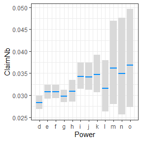

```r
visreg(m1, "Power", type="conditional", scale="response", gg=TRUE, rug=FALSE, partial=FALSE) + theme_bw()
```

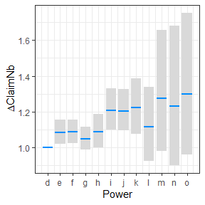

```r
visreg(m1, "Power", type="contrast", scale="response", gg=TRUE, rug=FALSE, partial=FALSE) + theme_bw()
```

##### Gas

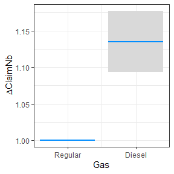

```r
visreg(m1, "Gas", type="contrast", scale="response", gg=TRUE, rug=FALSE, partial=FALSE) + theme_bw()
```

##### Region

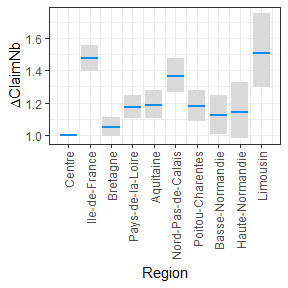

```r
visreg(m1, "Region", type="contrast", scale="response", gg=TRUE, rug=FALSE, partial=FALSE) + theme_bw() +
  theme(axis.text.x = element_text(angle = 90, vjust = 0.5, hjust=1))
```

##### Brand

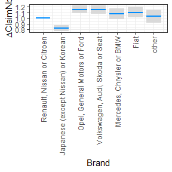

```r
visreg(m1, "Brand", type="contrast", scale="response", gg=TRUE, rug=FALSE, partial=FALSE) + theme_bw() +
  theme(axis.text.x = element_text(angle = 90, vjust = 0.5, hjust=1))
```

#### Comparing two models

We see some levels of some variables appear to be not significantly different from 0 (or 1 on the response scale). Moreover, it could be that some levels appear to be significantly different from 0, but are not significantly different from each other and could be merged.

If we wish to perform a likelihood ratio test between the full model $m_1$ and the model without any explanatory variables $m_0$ :

```r
anova(m0, m1, test = "Chisq")
```

```
## Analysis of Deviance Table
##
## Model 1: ClaimNb ~ offset(log(Exposure))
## Model 2: ClaimNb ~ offset(log(Exposure)) + Power + Gas + Brand + Region
##   Resid. Df Resid. Dev Df Deviance  Pr(>Chi)
## 1    328691      84299
## 2    328664      83916 27   382.74 < 2.2e-16 ***
## ---
## Signif. codes:  0 '***' 0.001 '**' 0.01 '*' 0.05 '.' 0.1 ' ' 1
```

Note:

Null Deviance = 2(LL(Saturated Model) - LL(Null Model)) with df = df_Sat - df_Null

Residual Deviance = 2(LL(Saturated Model) - LL(Proposed Model)) with df = df_Sat - df_Proposed

##### Predict claim frequencies

If we want to predict claim frequencies, we can directly use the predict function. We need to specify that the output needs to be of *type = “response”*, so that we obtain claim frequencies, rather than the linear predictor (on the “score” scale). For example, for the first four lines of the testing_set, we get:

```r
predict(m1, head(testing_set, 4), type="response")
```

```
##           1           2           3           4
## 0.005607189 0.002614029 0.061326100 0.013401838
```

### Offset or weights ?

Let us compare the previous model with the following model, which, some call a “Poisson rate model”)

```r
m2 = suppressWarnings(glm(ClaimNb/Exposure ~ Power + Gas + Brand + Region,
         data = training_set,
         weight = training_set$Exposure,
         family = poisson(link = log)))
summary(m2)
```

```
##
## Call:
## glm(formula = ClaimNb/Exposure ~ Power + Gas + Brand + Region,
##     family = poisson(link = log), data = training_set, weights = training_set$Exposure)
##
## Coefficients:
##                                         Estimate Std. Error  z value Pr(>|z|)
## (Intercept)                             -2.92738    0.02686 -108.978  < 2e-16
## Powere                                   0.08199    0.03121    2.627 0.008623
## Powerf                                   0.08333    0.03058    2.725 0.006431
## Powerg                                   0.04901    0.03044    1.610 0.107361
## Powerh                                   0.08583    0.04350    1.973 0.048480
## Poweri                                   0.18977    0.04842    3.920 8.87e-05
## Powerj                                   0.18583    0.04873    3.814 0.000137
## Powerk                                   0.20036    0.06432    3.115 0.001839
## Powerl                                   0.10847    0.09419    1.152 0.249486
## Powerm                                   0.24356    0.13331    1.827 0.067686
## Powern                                   0.20713    0.15903    1.302 0.192759
## Powero                                   0.26127    0.15325    1.705 0.088217
## GasDiesel                                0.12636    0.01886    6.700 2.09e-11
## BrandJapanese (except Nissan) or Korean -0.19473    0.03059   -6.365 1.95e-10
## BrandOpel, General Motors or Ford        0.14284    0.02983    4.788 1.68e-06
## BrandVolkswagen, Audi, Skoda or Seat     0.14182    0.03169    4.475 7.62e-06
## BrandMercedes, Chrysler or BMW           0.07159    0.04424    1.618 0.105666
## BrandFiat                                0.09812    0.04380    2.240 0.025063
## Brandother                               0.03085    0.05674    0.544 0.586673
## RegionIle-de-France                      0.38849    0.02835   13.701  < 2e-16
## RegionBretagne                           0.04931    0.02954    1.670 0.095012
## RegionPays-de-la-Loire                   0.15946    0.03129    5.096 3.46e-07
## RegionAquitaine                          0.17098    0.03795    4.505 6.62e-06
## RegionNord-Pas-de-Calais                 0.31214    0.03946    7.910 2.58e-15
## RegionPoitou-Charentes                   0.16466    0.04142    3.975 7.03e-05
## RegionBasse-Normandie                    0.11350    0.05389    2.106 0.035186
## RegionHaute-Normandie                    0.13236    0.07686    1.722 0.085060
## RegionLimousin                           0.41227    0.07692    5.360 8.34e-08
##
## (Intercept)                             ***
## Powere                                  **
## Powerf                                  **
## Powerg
```

[output cut: 19 more lines]

```
## RegionNord-Pas-de-Calais                ***
## RegionPoitou-Charentes                  ***
## RegionBasse-Normandie                   *
## RegionHaute-Normandie                   .
## RegionLimousin                          ***
## ---
## Signif. codes:  0 '***' 0.001 '**' 0.01 '*' 0.05 '.' 0.1 ' ' 1
##
## (Dispersion parameter for poisson family taken to be 1)
##
##     Null deviance: 84299  on 328691  degrees of freedom
## Residual deviance: 83916  on 328664  degrees of freedom
## AIC: Inf
##
## Number of Fisher Scoring iterations: 6
```

Let us compare the coefficients

```r
cbind(m1$coef, m2$coef)
```

```
##                                                [,1]        [,2]
## (Intercept)                             -2.92738024 -2.92738024
## Powere                                   0.08198571  0.08198571
## Powerf                                   0.08333279  0.08333279
## Powerg                                   0.04900718  0.04900718
## Powerh                                   0.08583395  0.08583395
## Poweri                                   0.18976716  0.18976716
## Powerj                                   0.18583253  0.18583253
## Powerk                                   0.20036184  0.20036184
## Powerl                                   0.10846684  0.10846685
## Powerm                                   0.24356215  0.24356215
## Powern                                   0.20713451  0.20713452
## Powero                                   0.26126817  0.26126817
## GasDiesel                                0.12636323  0.12636323
## BrandJapanese (except Nissan) or Korean -0.19472915 -0.19472916
## BrandOpel, General Motors or Ford        0.14283577  0.14283577
## BrandVolkswagen, Audi, Skoda or Seat     0.14181615  0.14181615
## BrandMercedes, Chrysler or BMW           0.07158682  0.07158682
## BrandFiat                                0.09812290  0.09812290
## Brandother                               0.03084709  0.03084709
## RegionIle-de-France                      0.38849148  0.38849148
## RegionBretagne                           0.04931014  0.04931014
## RegionPays-de-la-Loire                   0.15945625  0.15945625
## RegionAquitaine                          0.17097891  0.17097891
## RegionNord-Pas-de-Calais                 0.31214444  0.31214443
## RegionPoitou-Charentes                   0.16466143  0.16466143
## RegionBasse-Normandie                    0.11349562  0.11349562
## RegionHaute-Normandie                    0.13235510  0.13235507
## RegionLimousin                           0.41227457  0.41227457
```

Why does that work ? See course notes or : https://stats.stackexchange.com/a/270151

### Remarks

Up to now, we have

1. Load the original dataset.
2. We have prepared the data in some way (relevel the factors we instance). We could have binned the continuous variables.
3. Run a model on these variables.
4. Predict for some new observations (-> testing set ?).

There are some flaws in the way of working.

- We should not prepare the data *before* splitting into training and testing set. Although, we did not include information from the testing set into the training set here, we could have done so, if, for example, we were to standardize some variables. Indeed, if we standardize a continuous variable by substracting the mean and dividing by the standard deviation, since we have computed the mean and the standard deviation on the whole dataset (rather than only on the training set), we include information about the testing_set into the training_set and the otherway around as well.
- What if new data comes ? How will we handle this ? Do we need to reprocess the data preparation again ? How do we keep track of all the preprocessing that we have done ?

One way to handle this issue correctly is working with **recipes** (https://recipes.tidymodels.org/index.html). So, let’s restart this session and use **recipes**.

We will reload the data from the parquet files and directly split the data into a training and a testing set.

## Restart with recipes

```r
dataset = read_parquet(file = "../data/dataset.parquet")

set.seed(21)
in_training = createDataPartition(dataset$ClaimNb, times = 1, p = 0.8, list = FALSE)
training_set = dataset[in_training, ]
testing_set = dataset[-in_training, ]
```

We can specify a *recipe* to prepare the data correctly. The idea is to define this once, and apply it on different datasets, so we don’t need to preprocess the data manually.

```r
rec_0 <- recipe(ClaimNb ~ Exposure + Power + Gas + Brand + Region, data = training_set) %>%
    step_relevel(Power, ref_level = "d") %>%
    step_relevel(Gas, ref_level = "Regular") %>%
    step_relevel(Region, ref_level = "Centre") %>%
    step_relevel(Brand, ref_level = "Renault, Nissan or Citroen") %>%
    prep()
rec_0
```

```
## ── Recipe ──────────────────────────────────────────────────────────────────────
```

```
## ── Inputs
```

```
## Number of variables by role
```

```
## outcome:   1
## predictor: 5
```

```
## ── Training information
```

```
## Training data contained 328692 data points and no incomplete rows.
```

```
## ── Operations
```

```
## • Re-order factor level to ref_level for: Power | Trained
```

```
## • Re-order factor level to ref_level for: Gas | Trained
```

```
## • Re-order factor level to ref_level for: Region | Trained
```

```
## • Re-order factor level to ref_level for: Brand | Trained
```

```r
output = bake(rec_0, new_data = head(training_set, 4))
output
```

```
## # A tibble: 4 × 6
##   Exposure Power Gas     Brand                              Region       ClaimNb
##      <dbl> <fct> <fct>   <fct>                              <fct>          <int>
## 1     0.84 g     Diesel  Japanese (except Nissan) or Korean Aquitaine          0
## 2     0.52 f     Regular Japanese (except Nissan) or Korean Nord-Pas-de…       0
## 3     0.45 f     Regular Japanese (except Nissan) or Korean Nord-Pas-de…       0
## 4     0.15 g     Diesel  Japanese (except Nissan) or Korean Pays-de-la-…       0
```

Let us check the reference levels of the output

```r
str(output)
```

```
## tibble [4 × 6] (S3: tbl_df/tbl/data.frame)
##  $ Exposure: num [1:4] 0.84 0.52 0.45 0.15
##  $ Power   : Factor w/ 12 levels "d","e","f","g",..: 4 3 3 4
##  $ Gas     : Factor w/ 2 levels "Regular","Diesel": 2 1 1 2
##  $ Brand   : Factor w/ 7 levels "Renault, Nissan or Citroen",..: 3 3 3 3
##  $ Region  : Factor w/ 10 levels "Centre","Aquitaine",..: 2 8 8 9
##  $ ClaimNb : int [1:4] 0 0 0 0
```

to be compared with

```r
str(training_set)
```

```
## tibble [328,692 × 10] (S3: tbl_df/tbl/data.frame)
##  $ PolicyID : Factor w/ 413169 levels "1","2","3","4",..: 2 3 4 5 6 7 10 11 12 13 ...
##  $ ClaimNb  : int [1:328692] 0 0 0 0 0 0 0 0 0 0 ...
##  $ Exposure : num [1:328692] 0.84 0.52 0.45 0.15 0.75 0.81 0.34 0.1 0.77 0.55 ...
##  $ Power    : Factor w/ 12 levels "d","e","f","g",..: 4 3 3 4 4 1 6 3 3 2 ...
##  $ CarAge   : int [1:328692] 0 2 2 0 0 1 0 2 2 0 ...
##  $ DriverAge: int [1:328692] 46 38 38 41 41 27 44 32 32 33 ...
##  $ Brand    : Factor w/ 7 levels "Fiat","Japanese (except Nissan) or Korean",..: 2 2 2 2 2 2 2 2 2 2 ...
##  $ Gas      : Factor w/ 2 levels "Diesel","Regular": 1 2 2 1 1 2 2 1 1 2 ...
##  $ Region   : Factor w/ 10 levels "Aquitaine","Basse-Normandie",..: 1 8 8 9 9 1 6 4 4 6 ...
##  $ Density  : int [1:328692] 76 3003 3003 60 60 695 27000 23 23 1746 ...
```

We can use the recipe on the training and the testing set, and construct the same GLM as above. We can check that the results are the same and that we can predict on the testing set

```r
train_baked = bake(rec_0, new_data = training_set)
test_baked = bake(rec_0, new_data = testing_set)

m3 = glm(ClaimNb ~ offset(log(Exposure)) + Power + Gas + Brand + Region, data = train_baked, family = poisson())
summary(m3)
```

```
##
## Call:
## glm(formula = ClaimNb ~ offset(log(Exposure)) + Power + Gas +
##     Brand + Region, family = poisson(), data = train_baked)
##
## Coefficients:
##                                         Estimate Std. Error  z value Pr(>|z|)
## (Intercept)                             -2.92738    0.02686 -108.980  < 2e-16
## Powere                                   0.08199    0.03121    2.627 0.008622
## Powerf                                   0.08333    0.03058    2.725 0.006430
## Powerg                                   0.04901    0.03044    1.610 0.107353
## Powerh                                   0.08583    0.04350    1.973 0.048475
## Poweri                                   0.18977    0.04841    3.920 8.87e-05
## Powerj                                   0.18583    0.04873    3.814 0.000137
## Powerk                                   0.20036    0.06432    3.115 0.001839
## Powerl                                   0.10847    0.09418    1.152 0.249470
## Powerm                                   0.24356    0.13330    1.827 0.067683
## Powern                                   0.20713    0.15903    1.302 0.192752
## Powero                                   0.26127    0.15324    1.705 0.088208
## GasDiesel                                0.12636    0.01886    6.700 2.09e-11
## BrandFiat                                0.09812    0.04380    2.240 0.025061
## BrandJapanese (except Nissan) or Korean -0.19473    0.03059   -6.365 1.95e-10
## BrandMercedes, Chrysler or BMW           0.07159    0.04424    1.618 0.105662
## BrandOpel, General Motors or Ford        0.14284    0.02983    4.788 1.68e-06
## Brandother                               0.03085    0.05674    0.544 0.586670
## BrandVolkswagen, Audi, Skoda or Seat     0.14182    0.03169    4.476 7.62e-06
## RegionAquitaine                          0.17098    0.03795    4.506 6.62e-06
## RegionBasse-Normandie                    0.11350    0.05389    2.106 0.035185
## RegionBretagne                           0.04931    0.02954    1.670 0.095010
## RegionHaute-Normandie                    0.13236    0.07685    1.722 0.085024
## RegionIle-de-France                      0.38849    0.02835   13.702  < 2e-16
## RegionLimousin                           0.41227    0.07692    5.360 8.34e-08
## RegionNord-Pas-de-Calais                 0.31214    0.03946    7.910 2.58e-15
## RegionPays-de-la-Loire                   0.15946    0.03129    5.096 3.46e-07
## RegionPoitou-Charentes                   0.16466    0.04142    3.975 7.03e-05
##
## (Intercept)                             ***
## Powere                                  **
## Powerf                                  **
## Powerg
```

[output cut: 19 more lines]

```
## RegionIle-de-France                     ***
## RegionLimousin                          ***
## RegionNord-Pas-de-Calais                ***
## RegionPays-de-la-Loire                  ***
## RegionPoitou-Charentes                  ***
## ---
## Signif. codes:  0 '***' 0.001 '**' 0.01 '*' 0.05 '.' 0.1 ' ' 1
##
## (Dispersion parameter for poisson family taken to be 1)
##
##     Null deviance: 84299  on 328691  degrees of freedom
## Residual deviance: 83916  on 328664  degrees of freedom
## AIC: 108979
##
## Number of Fisher Scoring iterations: 6
```

```r
coefs_m1 = as.data.frame(m1$coef) %>% tibble::rownames_to_column()
coefs_m3 = as.data.frame(m3$coef) %>% tibble::rownames_to_column()

coefs_m1 %>% left_join(coefs_m3)
```

```
##                                    rowname     m1$coef     m3$coef
## 1                              (Intercept) -2.92738024 -2.92738024
## 2                                   Powere  0.08198571  0.08198571
## 3                                   Powerf  0.08333279  0.08333279
## 4                                   Powerg  0.04900718  0.04900718
## 5                                   Powerh  0.08583395  0.08583395
## 6                                   Poweri  0.18976716  0.18976716
## 7                                   Powerj  0.18583253  0.18583253
## 8                                   Powerk  0.20036184  0.20036184
## 9                                   Powerl  0.10846684  0.10846684
## 10                                  Powerm  0.24356215  0.24356215
## 11                                  Powern  0.20713451  0.20713451
## 12                                  Powero  0.26126817  0.26126817
## 13                               GasDiesel  0.12636323  0.12636323
## 14 BrandJapanese (except Nissan) or Korean -0.19472915 -0.19472915
## 15       BrandOpel, General Motors or Ford  0.14283577  0.14283577
## 16    BrandVolkswagen, Audi, Skoda or Seat  0.14181615  0.14181615
## 17          BrandMercedes, Chrysler or BMW  0.07158682  0.07158682
## 18                               BrandFiat  0.09812290  0.09812290
## 19                              Brandother  0.03084709  0.03084709
## 20                     RegionIle-de-France  0.38849148  0.38849148
## 21                          RegionBretagne  0.04931014  0.04931014
## 22                  RegionPays-de-la-Loire  0.15945625  0.15945625
## 23                         RegionAquitaine  0.17097891  0.17097891
## 24                RegionNord-Pas-de-Calais  0.31214444  0.31214444
## 25                  RegionPoitou-Charentes  0.16466143  0.16466143
## 26                   RegionBasse-Normandie  0.11349562  0.11349562
## 27                   RegionHaute-Normandie  0.13235510  0.13235510
## 28                          RegionLimousin  0.41227457  0.41227457
```

```r
predict(m3, head(test_baked), type="response")
```

```
##           1           2           3           4           5           6
## 0.005607189 0.002614029 0.061326100 0.013401838 0.009427595 0.055560893
```

**But,** we still need to bake the testing set before calling the predict function. **What if we don’t want to call this bake function anymore ?**

## Use Workflows and parsnip to specify model

We can define a workflow that first prepares the data and then goes into the model to either fit or predict.

A list of models that work with parsnip is provided here: https://www.tidymodels.org/find/parsnip/

```r
# Copy paste from above:
rec_4 <- recipe(ClaimNb ~ Power + Gas + Region + Brand + Exposure, data = training_set) %>% # Which columns do we need ?
    step_relevel(Power, ref_level = "d") %>%
    step_relevel(Gas, ref_level = "Regular") %>%
    step_relevel(Region, ref_level = "Centre") %>%
    step_relevel(Brand, ref_level = "Renault, Nissan or Citroen") %>%
    prep()
```

```r
bake(rec_4, head(training_set, 4))
```

```
## # A tibble: 4 × 6
##   Power Gas     Region             Brand                        Exposure ClaimNb
##   <fct> <fct>   <fct>              <fct>                           <dbl>   <int>
## 1 g     Diesel  Aquitaine          Japanese (except Nissan) or…     0.84       0
## 2 f     Regular Nord-Pas-de-Calais Japanese (except Nissan) or…     0.52       0
## 3 f     Regular Nord-Pas-de-Calais Japanese (except Nissan) or…     0.45       0
## 4 g     Diesel  Pays-de-la-Loire   Japanese (except Nissan) or…     0.15       0
```

Along with the *workflows* package, we can define a whole .. workflow. This will only define the workflow. No fit is done at this point

```r
m4_mod = poisson_reg() %>%
  set_engine("glm")

rec_4 <- recipe(ClaimNb ~ Power + Gas + Region + Brand + Exposure, data = training_set) %>% # Which columns do we need ?
    step_relevel(Power, ref_level = "d") %>%
    step_relevel(Gas, ref_level = "Regular") %>%
    step_relevel(Region, ref_level = "Centre") %>%
    step_relevel(Brand, ref_level = "Renault, Nissan or Citroen")


m4_wflow <-
  workflow() %>%
  add_recipe(rec_4) %>%
  add_model(m4_mod, formula = ClaimNb ~ Power + Gas + Region + Brand + offset(log(Exposure))) # Formula of the model

m4_wflow
```

```
## ══ Workflow ════════════════════════════════════════════════════════════════════
## Preprocessor: Recipe
## Model: poisson_reg()
##
## ── Preprocessor ────────────────────────────────────────────────────────────────
## 4 Recipe Steps
##
## • step_relevel()
## • step_relevel()
## • step_relevel()
## • step_relevel()
##
## ── Model ───────────────────────────────────────────────────────────────────────
## Poisson Regression Model Specification (regression)
##
## Computational engine: glm
```

We can fit, using the function fit.

The fit will consist in “baking” the data using the provided recipe, and estimate the coefficients of the GLM

```r
m4_fit <- fit(m4_wflow, data = training_set)
```

```r
# extract_fit_engine(m4_fit) is the GLM object
# We can call the summary function on it
summary(extract_fit_engine(m4_fit))
```

```
##
## Call:
## stats::glm(formula = ClaimNb ~ Power + Gas + Region + Brand +
##     offset(log(Exposure)), family = stats::poisson, data = data)
##
## Coefficients:
##                                         Estimate Std. Error  z value Pr(>|z|)
## (Intercept)                             -2.92738    0.02686 -108.980  < 2e-16
## Powere                                   0.08199    0.03121    2.627 0.008622
## Powerf                                   0.08333    0.03058    2.725 0.006430
## Powerg                                   0.04901    0.03044    1.610 0.107353
## Powerh                                   0.08583    0.04350    1.973 0.048475
## Poweri                                   0.18977    0.04841    3.920 8.87e-05
## Powerj                                   0.18583    0.04873    3.814 0.000137
## Powerk                                   0.20036    0.06432    3.115 0.001839
## Powerl                                   0.10847    0.09418    1.152 0.249470
## Powerm                                   0.24356    0.13330    1.827 0.067683
## Powern                                   0.20713    0.15903    1.302 0.192752
## Powero                                   0.26127    0.15324    1.705 0.088208
## GasDiesel                                0.12636    0.01886    6.700 2.09e-11
## RegionAquitaine                          0.17098    0.03795    4.506 6.62e-06
## RegionBasse-Normandie                    0.11350    0.05389    2.106 0.035185
## RegionBretagne                           0.04931    0.02954    1.670 0.095010
## RegionHaute-Normandie                    0.13236    0.07685    1.722 0.085024
## RegionIle-de-France                      0.38849    0.02835   13.702  < 2e-16
## RegionLimousin                           0.41227    0.07692    5.360 8.34e-08
## RegionNord-Pas-de-Calais                 0.31214    0.03946    7.910 2.58e-15
## RegionPays-de-la-Loire                   0.15946    0.03129    5.096 3.46e-07
## RegionPoitou-Charentes                   0.16466    0.04142    3.975 7.03e-05
## BrandFiat                                0.09812    0.04380    2.240 0.025061
## BrandJapanese (except Nissan) or Korean -0.19473    0.03059   -6.365 1.95e-10
## BrandMercedes, Chrysler or BMW           0.07159    0.04424    1.618 0.105662
## BrandOpel, General Motors or Ford        0.14284    0.02983    4.788 1.68e-06
## Brandother                               0.03085    0.05674    0.544 0.586670
## BrandVolkswagen, Audi, Skoda or Seat     0.14182    0.03169    4.476 7.62e-06
##
## (Intercept)                             ***
## Powere                                  **
## Powerf                                  **
## Powerg
```

[output cut: 19 more lines]

```
## BrandJapanese (except Nissan) or Korean ***
## BrandMercedes, Chrysler or BMW
## BrandOpel, General Motors or Ford       ***
## Brandother
## BrandVolkswagen, Audi, Skoda or Seat    ***
## ---
## Signif. codes:  0 '***' 0.001 '**' 0.01 '*' 0.05 '.' 0.1 ' ' 1
##
## (Dispersion parameter for poisson family taken to be 1)
##
##     Null deviance: 84299  on 328691  degrees of freedom
## Residual deviance: 83916  on 328664  degrees of freedom
## AIC: 108979
##
## Number of Fisher Scoring iterations: 6
```

What if we want to predict claim frequencies from the testing set ?

```r
predict(m4_fit, head(testing_set, 4))
```

```
## # A tibble: 4 × 1
##     .pred
##     <dbl>
## 1 0.00561
## 2 0.00261
## 3 0.0613
## 4 0.0134
```

Do the predictions match what we’ve done before ?

```r
max(abs(predict(m4_fit, testing_set) - predict(m1, testing_set, type="response")))
```

```
## [1] 3.981537e-14
```

What if the new data comes in as a text file ? Do we need to specify what variables are factors ?

```r
new_data = data.frame(
    "Exposure" = 0.8,
    "Power" = 'f',
    "Brand" = "other",
    "Gas" = "Regular",
    "Region" = "Centre"
    )

predict(m4_fit, new_data)
```

```
## # A tibble: 1 × 1
##    .pred
##    <dbl>
## 1 0.0480
```

## Build Model with all features

Now that we have understood how to build GLM models with workflows and recipes, we can use all the variables from the dataset. We will also include some interaction terms.

```r
rec_5 <- recipe(ClaimNb ~ Power + Gas + Region + Brand + Exposure, data = training_set) %>% # Which columns do we need ?
    step_relevel(Power, ref_level = "d") %>%
    step_relevel(Gas, ref_level = "Regular") %>%
    step_relevel(Region, ref_level = "Centre") %>%
    step_relevel(Brand, ref_level = "Renault, Nissan or Citroen")

m5_mod = poisson_reg() %>%
  set_engine("glm")

m5_wflow <-
  workflow() %>%
  add_model(m5_mod, formula = ClaimNb ~ offset(log(Exposure)) +
                                        Power +
                                        Gas +
                                        Region +
                                        Brand +
                                        Gas * Power +
                                        Gas * Region) %>% # Formula of the model
  add_recipe(rec_5)
m5_fit = m5_wflow %>% fit(training_set)
```

```r
summary(extract_fit_engine(m5_fit))
```

```
##
## Call:
## stats::glm(formula = ClaimNb ~ offset(log(Exposure)) + Power +
##     Gas + Region + Brand + Gas * Power + Gas * Region, family = stats::poisson,
##     data = data)
##
## Coefficients:
##                                          Estimate Std. Error z value Pr(>|z|)
## (Intercept)                             -2.925703   0.031537 -92.769  < 2e-16
## Powere                                   0.033507   0.040333   0.831 0.406109
## Powerf                                   0.012188   0.043242   0.282 0.778054
## Powerg                                   0.118517   0.037132   3.192 0.001414
## Powerh                                   0.179694   0.068533   2.622 0.008741
## Poweri                                   0.230044   0.055140   4.172 3.02e-05
## Powerj                                   0.276424   0.064733   4.270 1.95e-05
## Powerk                                   0.226365   0.085561   2.646 0.008153
## Powerl                                   0.114533   0.179604   0.638 0.523670
## Powerm                                   0.238417   0.149455   1.595 0.110656
## Powern                                   0.223722   0.169844   1.317 0.187765
## Powero                                   0.343410   0.167267   2.053 0.040066
## GasDiesel                                0.141161   0.059528   2.371 0.017724
## RegionAquitaine                          0.142682   0.055834   2.555 0.010605
## RegionBasse-Normandie                    0.204736   0.076210   2.686 0.007221
## RegionBretagne                          -0.001434   0.043719  -0.033 0.973835
## RegionHaute-Normandie                    0.020488   0.123979   0.165 0.868747
## RegionIle-de-France                      0.372615   0.037102  10.043  < 2e-16
## RegionLimousin                           0.444501   0.119070   3.733 0.000189
## RegionNord-Pas-de-Calais                 0.320808   0.060087   5.339 9.34e-08
## RegionPays-de-la-Loire                   0.117122   0.045738   2.561 0.010445
## RegionPoitou-Charentes                   0.136912   0.061250   2.235 0.025398
## BrandFiat                                0.108400   0.043906   2.469 0.013553
## BrandJapanese (except Nissan) or Korean -0.181479   0.030968  -5.860 4.62e-09
## BrandMercedes, Chrysler or BMW           0.096779   0.044829   2.159 0.030862
## BrandOpel, General Motors or Ford        0.142572   0.030202   4.721 2.35e-06
## Brandother                               0.040862   0.056867   0.719 0.472422
## BrandVolkswagen, Audi, Skoda or Seat     0.135868   0.032029   4.242 2.22e-05
## Powere:GasDiesel                         0.067126   0.067703   0.991 0.321452
## Powerf:GasDiesel                         0.075485   0.068347   1.104 0.269404
## Powerg:GasDiesel                        -0.167859   0.067031  -2.504 0.012273
## Powerh:GasDiesel                        -0.165573   0.094214  -1.757 0.078846
```

[output cut: 60 more lines]

```
## GasDiesel:RegionIle-de-France
## GasDiesel:RegionLimousin
## GasDiesel:RegionNord-Pas-de-Calais
## GasDiesel:RegionPays-de-la-Loire
## GasDiesel:RegionPoitou-Charentes
## ---
## Signif. codes:  0 '***' 0.001 '**' 0.01 '*' 0.05 '.' 0.1 ' ' 1
##
## (Dispersion parameter for poisson family taken to be 1)
##
##     Null deviance: 84299  on 328691  degrees of freedom
## Residual deviance: 83870  on 328644  degrees of freedom
## AIC: 108973
##
## Number of Fisher Scoring iterations: 6
```

### Cross-validation

We will use cross-validation to find the relevant features to keep and how to bin the variables.

```r
folds = training_set %>% vfold_cv(strata = ClaimNb, v = 5)
```

```r
res = fit_resamples(m5_wflow,
                    resamples = folds,
                    metrics = metric_set(poisson_log_loss))
```

```r
# Collect metrics and format the 'mean' and 'std_err' columns for more decimal places
collect_metrics(res) %>%
  mutate(
    mean = sprintf("%.6f", mean),
    std_err = sprintf("%.6f", std_err)
  )
```

```
## # A tibble: 1 × 6
##   .metric          .estimator mean         n std_err  .config
##   <chr>            <chr>      <chr>    <int> <chr>    <chr>
## 1 poisson_log_loss standard   0.165817     5 0.001183 Preprocessor1_Model1
```

### Without interactions

```r
rec_6 <- recipe(ClaimNb ~ Power + Gas + Region + Brand + Exposure, data = training_set) %>% # Which columns do we need ?
    step_relevel(Power, ref_level = "d") %>%
    step_relevel(Gas, ref_level = "Regular") %>%
    step_relevel(Region, ref_level = "Centre") %>%
    step_relevel(Brand, ref_level = "Renault, Nissan or Citroen")

m6_mod = poisson_reg() %>%
  set_engine("glm")

m6_wflow <-
  workflow() %>%
  add_model(m6_mod, formula = ClaimNb ~ offset(log(Exposure)) + . - Exposure) %>% # Formula of the model
  add_recipe(rec_6)
m6_fit = m6_wflow %>%
    fit(training_set)
```

```r
res = fit_resamples(m6_wflow,
                    resamples = folds,
                    metrics = metric_set(poisson_log_loss))

# Collect metrics and format the 'mean' and 'std_err' columns for more decimal places
collect_metrics(res) %>%
  mutate(
    mean = sprintf("%.6f", mean),
    std_err = sprintf("%.6f", std_err)
  )
```

```
## # A tibble: 1 × 6
##   .metric          .estimator mean         n std_err  .config
##   <chr>            <chr>      <chr>    <int> <chr>    <chr>
## 1 poisson_log_loss standard   0.165793     5 0.001202 Preprocessor1_Model1
```

We will not keep the interactions for now.

We can now try to merge some of the levels that appear to be not significantly different.

### Group some Brands

```r
rec_7 <- recipe(ClaimNb ~ Power + Gas + Region + Brand + Exposure, data = training_set) %>% # Which columns do we need ?
    step_relevel(Power, ref_level = "d") %>%
    step_relevel(Gas, ref_level = "Regular") %>%
    step_relevel(Region, ref_level = "Centre") %>%
    step_relevel(Brand, ref_level = "Renault, Nissan or Citroen") %>%
    step_mutate(Brand = forcats::fct_collapse(Brand, A = c("Fiat", "Mercedes, Chrysler or BMW",
                                                     "Opel, General Motors or Ford",
                                                     "other",
                                                     "Volkswagen, Audi, Skoda or Seat")))

m7_mod = poisson_reg() %>%
  set_engine("glm")

m7_wflow <-
  workflow() %>%
  add_model(m7_mod, formula = ClaimNb ~ offset(log(Exposure)) + . - Exposure) %>% # Formula of the model
  add_recipe(rec_7)

res7 = fit_resamples(m7_wflow,
                    resamples = folds,
                    metrics = metric_set(poisson_log_loss))
collect_metrics(res7) %>%
  mutate(
    mean = sprintf("%.6f", mean),
    std_err = sprintf("%.6f", std_err)
  )
```

```
## # A tibble: 1 × 6
##   .metric          .estimator mean         n std_err  .config
##   <chr>            <chr>      <chr>    <int> <chr>    <chr>
## 1 poisson_log_loss standard   0.165781     5 0.001197 Preprocessor1_Model1
```

```r
m7_fit = m7_wflow %>%
    fit(training_set)
summary(extract_fit_engine(m7_fit))
```

```
##
## Call:
## stats::glm(formula = ClaimNb ~ offset(log(Exposure)) + . - Exposure,
##     family = stats::poisson, data = data)
##
## Coefficients:
##                                         Estimate Std. Error  z value Pr(>|z|)
## (Intercept)                             -2.92698    0.02673 -109.511  < 2e-16
## Powere                                   0.08818    0.03101    2.843 0.004465
## Powerf                                   0.08505    0.03050    2.789 0.005293
## Powerg                                   0.04737    0.03029    1.564 0.117856
## Powerh                                   0.07704    0.04330    1.779 0.075194
## Poweri                                   0.17928    0.04796    3.738 0.000186
## Powerj                                   0.17717    0.04832    3.666 0.000246
## Powerk                                   0.18850    0.06378    2.956 0.003121
## Powerl                                   0.08957    0.09278    0.965 0.334343
## Powerm                                   0.20938    0.13060    1.603 0.108906
## Powern                                   0.18597    0.15818    1.176 0.239711
## Powero                                   0.25419    0.15298    1.662 0.096606
## GasDiesel                                0.12530    0.01879    6.669 2.57e-11
## RegionAquitaine                          0.17122    0.03794    4.512 6.41e-06
## RegionBasse-Normandie                    0.11234    0.05388    2.085 0.037085
## RegionBretagne                           0.04948    0.02953    1.676 0.093825
## RegionHaute-Normandie                    0.13115    0.07685    1.707 0.087875
## RegionIle-de-France                      0.38793    0.02835   13.684  < 2e-16
## RegionLimousin                           0.41228    0.07692    5.360 8.31e-08
## RegionNord-Pas-de-Calais                 0.31337    0.03946    7.942 1.99e-15
## RegionPays-de-la-Loire                   0.15962    0.03129    5.102 3.37e-07
## RegionPoitou-Charentes                   0.16473    0.04142    3.977 6.96e-05
## BrandA                                   0.11697    0.02009    5.824 5.76e-09
## BrandJapanese (except Nissan) or Korean -0.19147    0.03054   -6.270 3.62e-10
##
## (Intercept)                             ***
## Powere                                  **
## Powerf                                  **
## Powerg
## Powerh                                  .
## Poweri                                  ***
## Powerj                                  ***
## Powerk                                  **
```

[output cut: 11 more lines]

```
## RegionNord-Pas-de-Calais                ***
## RegionPays-de-la-Loire                  ***
## RegionPoitou-Charentes                  ***
## BrandA                                  ***
## BrandJapanese (except Nissan) or Korean ***
## ---
## Signif. codes:  0 '***' 0.001 '**' 0.01 '*' 0.05 '.' 0.1 ' ' 1
##
## (Dispersion parameter for poisson family taken to be 1)
##
##     Null deviance: 84299  on 328691  degrees of freedom
## Residual deviance: 83922  on 328668  degrees of freedom
## AIC: 108976
##
## Number of Fisher Scoring iterations: 6
```

### Group some levels of Power

For example, one could regroup levels e-f-g-h of variable power.

```r
rec_8 <- recipe(ClaimNb ~ Power + Gas + Region + Brand + Exposure, data = training_set) %>% # Which columns do we need ?
    step_relevel(Power, ref_level = "d") %>%
    step_relevel(Gas, ref_level = "Regular") %>%
    step_relevel(Region, ref_level = "Centre") %>%
    step_relevel(Brand, ref_level = "Renault, Nissan or Citroen") %>%
    step_mutate(Brand = forcats::fct_collapse(Brand, A = c("Fiat", "Mercedes, Chrysler or BMW",
                                                     "Opel, General Motors or Ford",
                                                     "other",
                                                     "Volkswagen, Audi, Skoda or Seat"))) %>%
    step_mutate(Power = forcats::fct_collapse(Power, "e-f-g-h" = c("e", "f", "g", "h")))
m8_mod = poisson_reg() %>%
  set_engine("glm")

m8_wflow <-
  workflow() %>%
  add_model(m8_mod, formula = ClaimNb ~ offset(log(Exposure)) + . - Exposure) %>% # Formula of the model
  add_recipe(rec_8)

res8 = fit_resamples(m8_wflow,
                    resamples = folds,
                    metrics = metric_set(poisson_log_loss))
collect_metrics(res8) %>%
  mutate(
    mean = sprintf("%.6f", mean),
    std_err = sprintf("%.6f", std_err)
  )
```

```
## # A tibble: 1 × 6
##   .metric          .estimator mean         n std_err  .config
##   <chr>            <chr>      <chr>    <int> <chr>    <chr>
## 1 poisson_log_loss standard   0.165777     5 0.001192 Preprocessor1_Model1
```

```r
m8_fit = m8_wflow %>%
    fit(training_set)
summary(extract_fit_engine(m8_fit))
```

```
##
## Call:
## stats::glm(formula = ClaimNb ~ offset(log(Exposure)) + . - Exposure,
##     family = stats::poisson, data = data)
##
## Coefficients:
##                                         Estimate Std. Error  z value Pr(>|z|)
## (Intercept)                             -2.92788    0.02670 -109.661  < 2e-16
## Powere-f-g-h                             0.07249    0.02622    2.765 0.005700
## Poweri                                   0.17905    0.04796    3.733 0.000189
## Powerj                                   0.17635    0.04831    3.651 0.000262
## Powerk                                   0.18774    0.06377    2.944 0.003239
## Powerl                                   0.08816    0.09276    0.950 0.341908
## Powerm                                   0.20891    0.13060    1.600 0.109675
## Powern                                   0.18587    0.15817    1.175 0.239950
## Powero                                   0.25478    0.15298    1.666 0.095812
## GasDiesel                                0.12878    0.01851    6.958 3.46e-12
## RegionAquitaine                          0.17216    0.03794    4.538 5.68e-06
## RegionBasse-Normandie                    0.11252    0.05388    2.088 0.036779
## RegionBretagne                           0.05029    0.02953    1.703 0.088492
## RegionHaute-Normandie                    0.13078    0.07685    1.702 0.088785
## RegionIle-de-France                      0.38866    0.02834   13.714  < 2e-16
## RegionLimousin                           0.41220    0.07691    5.359 8.36e-08
## RegionNord-Pas-de-Calais                 0.31441    0.03945    7.971 1.58e-15
## RegionPays-de-la-Loire                   0.15962    0.03129    5.102 3.37e-07
## RegionPoitou-Charentes                   0.16461    0.04141    3.975 7.04e-05
## BrandA                                   0.11735    0.01995    5.882 4.06e-09
## BrandJapanese (except Nissan) or Korean -0.19355    0.03036   -6.375 1.83e-10
##
## (Intercept)                             ***
## Powere-f-g-h                            **
## Poweri                                  ***
## Powerj                                  ***
## Powerk                                  **
## Powerl
## Powerm
## Powern
## Powero                                  .
## GasDiesel                               ***
## RegionAquitaine                         ***
## RegionBasse-Normandie                   *
## RegionBretagne                          .
## RegionHaute-Normandie                   .
## RegionIle-de-France                     ***
## RegionLimousin                          ***
## RegionNord-Pas-de-Calais                ***
## RegionPays-de-la-Loire                  ***
## RegionPoitou-Charentes                  ***
## BrandA                                  ***
## BrandJapanese (except Nissan) or Korean ***
## ---
## Signif. codes:  0 '***' 0.001 '**' 0.01 '*' 0.05 '.' 0.1 ' ' 1
##
## (Dispersion parameter for poisson family taken to be 1)
##
##     Null deviance: 84299  on 328691  degrees of freedom
## Residual deviance: 83924  on 328671  degrees of freedom
## AIC: 108973
##
## Number of Fisher Scoring iterations: 6
```

Let us try a different regrouping:

```r
rec_8 <- recipe(ClaimNb ~ Power + Gas + Region + Brand + Exposure, data = training_set) %>% # Which columns do we need ?
    step_relevel(Power, ref_level = "d") %>%
    step_relevel(Gas, ref_level = "Regular") %>%
    step_relevel(Region, ref_level = "Centre") %>%
    step_relevel(Brand, ref_level = "Renault, Nissan or Citroen") %>%
    step_mutate(Brand = forcats::fct_collapse(Brand, A = c("Fiat", "Mercedes, Chrysler or BMW",
                                                     "Opel, General Motors or Ford",
                                                     "other",
                                                     "Volkswagen, Audi, Skoda or Seat"))) %>%
    step_mutate(Power = forcats::fct_collapse(Power, "d-e" = c("d", "e"), "f-g-h" = c("f", "g", "h")))

m8_mod = poisson_reg() %>%
  set_engine("glm")

m8_wflow <-
  workflow() %>%
  add_model(m8_mod, formula = ClaimNb ~ offset(log(Exposure)) + . - Exposure) %>% # Formula of the model
  add_recipe(rec_8)

res8 = fit_resamples(m8_wflow,
                    resamples = folds,
                    metrics = metric_set(poisson_log_loss))
collect_metrics(res8) %>%
  mutate(
    mean = sprintf("%.6f", mean),
    std_err = sprintf("%.6f", std_err)
  )
```

```
## # A tibble: 1 × 6
##   .metric          .estimator mean         n std_err  .config
##   <chr>            <chr>      <chr>    <int> <chr>    <chr>
## 1 poisson_log_loss standard   0.165787     5 0.001188 Preprocessor1_Model1
```

We can see that with the new regrouping, its cross-validation error increases. Finally, let us regroup the some other levels

```r
rec_9 <- recipe(ClaimNb ~ Power + Gas + Region + Brand + Exposure, data = training_set) %>% # Which columns do we need ?
    step_relevel(Power, ref_level = "d") %>%
    step_relevel(Gas, ref_level = "Regular") %>%
    step_relevel(Region, ref_level = "Centre") %>%
    step_relevel(Brand, ref_level = "Renault, Nissan or Citroen") %>%
    step_mutate(Brand = forcats::fct_collapse(Brand, A = c("Fiat", "Mercedes, Chrysler or BMW",
                                                           "Opel, General Motors or Ford",
                                                           "other",
                                                           "Volkswagen, Audi, Skoda or Seat"))) %>%
    step_mutate(Power = forcats::fct_collapse(Power,
                                                 "e-f-g-h" = c("e", "f", "g", "h"),
                                                 "i-j-k-l-m" = c("i", "j", "k", "l", "m"),
                                                 "n-o" = c("n", "o")
                                             ))

m9_mod = poisson_reg() %>%
  set_engine("glm")

m9_wflow <-
  workflow() %>%
  add_model(m9_mod, formula = ClaimNb ~ offset(log(Exposure)) + . - Exposure) %>% # Formula of the model
  add_recipe(rec_9)

res9 = fit_resamples(m9_wflow,
                    resamples = folds,
                    metrics = metric_set(poisson_log_loss))
collect_metrics(res9) %>%
  mutate(
    mean = sprintf("%.6f", mean),
    std_err = sprintf("%.6f", std_err)
  )
```

```
## # A tibble: 1 × 6
##   .metric          .estimator mean         n std_err  .config
##   <chr>            <chr>      <chr>    <int> <chr>    <chr>
## 1 poisson_log_loss standard   0.165762     5 0.001198 Preprocessor1_Model1
```

```r
m9_fit = m9_wflow %>%
    fit(training_set)
summary(extract_fit_engine(m9_fit))
```

```
##
## Call:
## stats::glm(formula = ClaimNb ~ offset(log(Exposure)) + . - Exposure,
##     family = stats::poisson, data = data)
##
## Coefficients:
##                                         Estimate Std. Error  z value Pr(>|z|)
## (Intercept)                             -2.92713    0.02667 -109.742  < 2e-16
## Powere-f-g-h                             0.07292    0.02621    2.782  0.00541
## Poweri-j-k-l-m                           0.17380    0.03441    5.051 4.40e-07
## Powern-o                                 0.22131    0.11122    1.990  0.04661
## GasDiesel                                0.12740    0.01839    6.929 4.22e-12
## RegionAquitaine                          0.17239    0.03793    4.545 5.50e-06
## RegionBasse-Normandie                    0.11241    0.05388    2.086  0.03694
## RegionBretagne                           0.05029    0.02952    1.703  0.08850
## RegionHaute-Normandie                    0.13038    0.07684    1.697  0.08973
## RegionIle-de-France                      0.38869    0.02833   13.719  < 2e-16
## RegionLimousin                           0.41214    0.07691    5.359 8.39e-08
## RegionNord-Pas-de-Calais                 0.31459    0.03944    7.977 1.50e-15
## RegionPays-de-la-Loire                   0.15954    0.03129    5.099 3.41e-07
## RegionPoitou-Charentes                   0.16473    0.04141    3.978 6.96e-05
## BrandA                                   0.11675    0.01990    5.866 4.46e-09
## BrandJapanese (except Nissan) or Korean -0.19535    0.03016   -6.476 9.39e-11
##
## (Intercept)                             ***
## Powere-f-g-h                            **
## Poweri-j-k-l-m                          ***
## Powern-o                                *
## GasDiesel                               ***
## RegionAquitaine                         ***
## RegionBasse-Normandie                   *
## RegionBretagne                          .
## RegionHaute-Normandie                   .
## RegionIle-de-France                     ***
## RegionLimousin                          ***
## RegionNord-Pas-de-Calais                ***
## RegionPays-de-la-Loire                  ***
## RegionPoitou-Charentes                  ***
## BrandA                                  ***
## BrandJapanese (except Nissan) or Korean ***
## ---
## Signif. codes:  0 '***' 0.001 '**' 0.01 '*' 0.05 '.' 0.1 ' ' 1
##
## (Dispersion parameter for poisson family taken to be 1)
##
##     Null deviance: 84299  on 328691  degrees of freedom
## Residual deviance: 83926  on 328676  degrees of freedom
## AIC: 108964
##
## Number of Fisher Scoring iterations: 6
```

Let us now regroup some regions, e.g. Pays de la loire et Poitou-Charentes for which coefficients are not so different.

```r
rec <- recipe(ClaimNb ~ Power + Gas + Region + Brand + Exposure, data = training_set) %>% # Which columns do we need ?
    step_relevel(Power, ref_level = "d") %>%
    step_relevel(Gas, ref_level = "Regular") %>%
    step_relevel(Region, ref_level = "Centre") %>%
    step_relevel(Brand, ref_level = "Renault, Nissan or Citroen") %>%
    step_mutate(Brand = forcats::fct_collapse(Brand, A = c("Fiat", "Mercedes, Chrysler or BMW",
                                                     "Opel, General Motors or Ford",
                                                     "other",
                                                     "Volkswagen, Audi, Skoda or Seat"))) %>%
    step_mutate(Power = forcats::fct_collapse(Power,
                                                 "e-f-g-h" = c("e", "f", "g", "h"),
                                                 "i-j-k-l-m" = c("i", "j", "k", "l", "m"),
                                                 "n-o" = c("n", "o")
                                                )) %>%
    step_mutate(Region = forcats::fct_collapse(Region,
                                                 "A" = c("Pays-de-la-Loire", "Poitou-Charentes", "Aquitaine")
                                                ))

m_mod = poisson_reg() %>%
  set_engine("glm")

m10_wflow <-
  workflow() %>%
  add_model(m_mod, formula = ClaimNb ~ offset(log(Exposure)) + . - Exposure) %>% # Formula of the model
  add_recipe(rec)

res10 = fit_resamples(m10_wflow,
                    resamples = folds,
                    metrics = metric_set(poisson_log_loss))
collect_metrics(res10) %>%
  mutate(
    mean = sprintf("%.6f", mean),
    std_err = sprintf("%.6f", std_err)
  )
```

```
## # A tibble: 1 × 6
##   .metric          .estimator mean         n std_err  .config
##   <chr>            <chr>      <chr>    <int> <chr>    <chr>
## 1 poisson_log_loss standard   0.165759     5 0.001198 Preprocessor1_Model1
```

## Consider the continuous variables

Let us first add the variables without any preprocessing.

```r
rec <- recipe(ClaimNb ~ DriverAge + CarAge + Power + Gas + Region + Brand + Exposure, data = training_set) %>% # Which columns do we need ?
    step_relevel(Power, ref_level = "d") %>%
    step_relevel(Gas, ref_level = "Regular") %>%
    step_relevel(Region, ref_level = "Centre") %>%
    step_relevel(Brand, ref_level = "Renault, Nissan or Citroen") %>%
    step_mutate(Brand = forcats::fct_collapse(Brand, A = c("Fiat", "Mercedes, Chrysler or BMW",
                                                     "Opel, General Motors or Ford",
                                                     "other",
                                                     "Volkswagen, Audi, Skoda or Seat"))) %>%
    step_mutate(Power = forcats::fct_collapse(Power,
                                                 "e-f-g-h" = c("e", "f", "g", "h"),
                                                 "i-j-k-l-m" = c("i", "j", "k", "l", "m"),
                                                 "n-o" = c("n", "o")
                                                )) %>%
    step_mutate(Region = forcats::fct_collapse(Region,
                                                 "A" = c("Pays-de-la-Loire", "Poitou-Charentes", "Aquitaine")
                                                ))

m_mod = poisson_reg() %>%
  set_engine("glm")

m10_wflow <-
  workflow() %>%
  add_model(m_mod, formula = ClaimNb ~ offset(log(Exposure)) + . - Exposure) %>% # Formula of the model
  add_recipe(rec)

res10 = fit_resamples(m10_wflow,
                    resamples = folds,
                    metrics = metric_set(poisson_log_loss))
collect_metrics(res10) %>%
  mutate(
    mean = sprintf("%.6f", mean),
    std_err = sprintf("%.6f", std_err)
  )
```

```
## # A tibble: 1 × 6
##   .metric          .estimator mean         n std_err  .config
##   <chr>            <chr>      <chr>    <int> <chr>    <chr>
## 1 poisson_log_loss standard   0.165338     5 0.001180 Preprocessor1_Model1
```

```r
m10_fit = m10_wflow %>%
    fit(training_set)
summary(extract_fit_engine(m10_fit))
```

```
##
## Call:
## stats::glm(formula = ClaimNb ~ offset(log(Exposure)) + . - Exposure,
##     family = stats::poisson, data = data)
##
## Coefficients:
##                                           Estimate Std. Error z value Pr(>|z|)
## (Intercept)                             -2.3259147  0.0449218 -51.777  < 2e-16
## DriverAge                               -0.0098563  0.0006363 -15.489  < 2e-16
## CarAge                                  -0.0122924  0.0018583  -6.615 3.72e-11
## Powere-f-g-h                             0.0752926  0.0262274   2.871  0.00409
## Poweri-j-k-l-m                           0.1930871  0.0343932   5.614 1.98e-08
## Powern-o                                 0.2358311  0.1112179   2.120  0.03397
## GasDiesel                                0.0836724  0.0186591   4.484 7.32e-06
## RegionA                                  0.1488080  0.0238067   6.251 4.09e-10
## RegionBasse-Normandie                    0.0948861  0.0539015   1.760  0.07835
## RegionBretagne                           0.0402349  0.0295613   1.361  0.17349
## RegionHaute-Normandie                    0.0947441  0.0768673   1.233  0.21774
## RegionIle-de-France                      0.3391864  0.0285335  11.887  < 2e-16
## RegionLimousin                           0.3965140  0.0769311   5.154 2.55e-07
## RegionNord-Pas-de-Calais                 0.2519749  0.0396145   6.361 2.01e-10
## BrandA                                   0.0806791  0.0200033   4.033 5.50e-05
## BrandJapanese (except Nissan) or Korean -0.2521117  0.0316680  -7.961 1.71e-15
##
## (Intercept)                             ***
## DriverAge                               ***
## CarAge                                  ***
## Powere-f-g-h                            **
## Poweri-j-k-l-m                          ***
## Powern-o                                *
## GasDiesel                               ***
## RegionA                                 ***
## RegionBasse-Normandie                   .
## RegionBretagne
## RegionHaute-Normandie
## RegionIle-de-France                     ***
## RegionLimousin                          ***
## RegionNord-Pas-de-Calais                ***
## BrandA                                  ***
## BrandJapanese (except Nissan) or Korean ***
## ---
## Signif. codes:  0 '***' 0.001 '**' 0.01 '*' 0.05 '.' 0.1 ' ' 1
##
## (Dispersion parameter for poisson family taken to be 1)
##
##     Null deviance: 84299  on 328691  degrees of freedom
## Residual deviance: 83647  on 328676  degrees of freedom
## AIC: 108686
##
## Number of Fisher Scoring iterations: 6
```

One possibility is to add polynomial terms. We then need to find the optimal degree of the polynomial. For example, let us consider a polynomial of degree 2 for DriverAge and a polynomial for CarAge.

```r
rec <- recipe(ClaimNb ~ DriverAge + CarAge + Power + Gas + Region + Brand + Exposure, data = training_set) %>% # Which columns do we need ?
    step_relevel(Power, ref_level = "d") %>%
    step_relevel(Gas, ref_level = "Regular") %>%
    step_relevel(Region, ref_level = "Centre") %>%
    step_relevel(Brand, ref_level = "Renault, Nissan or Citroen") %>%
    step_mutate(Brand = forcats::fct_collapse(Brand, A = c("Fiat", "Mercedes, Chrysler or BMW",
                                                     "Opel, General Motors or Ford",
                                                     "other",
                                                     "Volkswagen, Audi, Skoda or Seat"))) %>%
    step_mutate(Power = forcats::fct_collapse(Power,
                                                 "e-f-g-h" = c("e", "f", "g", "h"),
                                                 "i-j-k-l-m" = c("i", "j", "k", "l", "m"),
                                                 "n-o" = c("n", "o")
                                                )) %>%
    step_mutate(Region = forcats::fct_collapse(Region,
                                                 "A" = c("Pays-de-la-Loire", "Poitou-Charentes", "Aquitaine")
                                                )) %>%
    step_poly(DriverAge, degree=2) %>%
    step_poly(CarAge, degree=2)

m_mod = poisson_reg() %>%
  set_engine("glm")

m11_wflow <-
  workflow() %>%
  add_model(m_mod, formula = ClaimNb ~ offset(log(Exposure)) + . - Exposure) %>% # Formula of the model
  add_recipe(rec)

res11 = fit_resamples(m11_wflow,
                    resamples = folds,
                    metrics = metric_set(poisson_log_loss))
collect_metrics(res11) %>%
  mutate(
    mean = sprintf("%.6f", mean),
    std_err = sprintf("%.6f", std_err)
  )
```

```
## # A tibble: 1 × 6
##   .metric          .estimator mean         n std_err  .config
##   <chr>            <chr>      <chr>    <int> <chr>    <chr>
## 1 poisson_log_loss standard   0.165069     5 0.001154 Preprocessor1_Model1
```

We can change the degree. After several trials and errors, we can find…

```r
rec <- recipe(ClaimNb ~ DriverAge + CarAge + Power + Gas + Region + Brand + Exposure, data = training_set) %>% # Which columns do we need ?
    step_relevel(Power, ref_level = "d") %>%
    step_relevel(Gas, ref_level = "Regular") %>%
    step_relevel(Region, ref_level = "Centre") %>%
    step_relevel(Brand, ref_level = "Renault, Nissan or Citroen") %>%
    step_mutate(Brand = forcats::fct_collapse(Brand, A = c("Fiat", "Mercedes, Chrysler or BMW",
                                                     "Opel, General Motors or Ford",
                                                     "other",
                                                     "Volkswagen, Audi, Skoda or Seat"))) %>%
    step_mutate(Power = forcats::fct_collapse(Power,
                                                 "e-f-g-h" = c("e", "f", "g", "h"),
                                                 "i-j-k-l-m" = c("i", "j", "k", "l", "m"),
                                                 "n-o" = c("n", "o")
                                                )) %>%
    step_mutate(Region = forcats::fct_collapse(Region,
                                                 "A" = c("Pays-de-la-Loire", "Poitou-Charentes", "Aquitaine")
                                                )) %>%
    step_poly(DriverAge, degree=7) %>%
    step_poly(CarAge, degree=2)
m_mod = poisson_reg() %>%
  set_engine("glm")

m11_wflow <-
  workflow() %>%
  add_model(m_mod, formula = ClaimNb ~ offset(log(Exposure)) + . - Exposure) %>% # Formula of the model
  add_recipe(rec)

res11 = fit_resamples(m11_wflow,
                    resamples = folds,
                    metrics = metric_set(poisson_log_loss))
collect_metrics(res11) %>%
  mutate(
    mean = sprintf("%.6f", mean),
    std_err = sprintf("%.6f", std_err)
  )
```

```
## # A tibble: 1 × 6
##   .metric          .estimator mean         n std_err  .config
##   <chr>            <chr>      <chr>    <int> <chr>    <chr>
## 1 poisson_log_loss standard   0.164456     5 0.001170 Preprocessor1_Model1
```

```r
m11_fit = m11_wflow %>%
    fit(training_set)
summary(extract_fit_engine(m11_fit))
```

```
##
## Call:
## stats::glm(formula = ClaimNb ~ offset(log(Exposure)) + . - Exposure,
##     family = stats::poisson, data = data)
##
## Coefficients:
##                                          Estimate Std. Error  z value Pr(>|z|)
## (Intercept)                              -2.93816    0.02757 -106.583  < 2e-16
## Powere-f-g-h                              0.09047    0.02627    3.444 0.000572
## Poweri-j-k-l-m                            0.23014    0.03453    6.665 2.65e-11
## Powern-o                                  0.29075    0.11128    2.613 0.008982
## GasDiesel                                 0.11582    0.01877    6.170 6.81e-10
## RegionA                                   0.16658    0.02382    6.993 2.69e-12
## RegionBasse-Normandie                     0.08869    0.05391    1.645 0.099968
## RegionBretagne                            0.05251    0.02959    1.774 0.075986
## RegionHaute-Normandie                     0.12038    0.07688    1.566 0.117367
## RegionIle-de-France                       0.37560    0.02856   13.153  < 2e-16
## RegionLimousin                            0.42372    0.07696    5.506 3.68e-08
## RegionNord-Pas-de-Calais                  0.27311    0.03962    6.893 5.46e-12
## BrandA                                    0.08714    0.02001    4.355 1.33e-05
## BrandJapanese (except Nissan) or Korean  -0.19633    0.03235   -6.069 1.29e-09
## DriverAge_poly_1                        -68.20369    5.04050  -13.531  < 2e-16
## DriverAge_poly_2                         50.59479    4.72944   10.698  < 2e-16
## DriverAge_poly_3                        -49.17063    4.67529  -10.517  < 2e-16
## DriverAge_poly_4                         64.41172    4.63685   13.891  < 2e-16
## DriverAge_poly_5                        -40.98919    4.62985   -8.853  < 2e-16
## DriverAge_poly_6                         -2.04858    4.55047   -0.450 0.652572
## DriverAge_poly_7                         12.64854    4.57601    2.764 0.005708
## CarAge_poly_1                           -37.57043    5.99167   -6.270 3.60e-10
## CarAge_poly_2                           -32.83930    5.78218   -5.679 1.35e-08
##
## (Intercept)                             ***
## Powere-f-g-h                            ***
## Poweri-j-k-l-m                          ***
## Powern-o                                **
## GasDiesel                               ***
## RegionA                                 ***
## RegionBasse-Normandie                   .
## RegionBretagne                          .
## RegionHaute-Normandie
```

[output cut: 9 more lines]

```
## DriverAge_poly_5                        ***
## DriverAge_poly_6
## DriverAge_poly_7                        **
## CarAge_poly_1                           ***
## CarAge_poly_2                           ***
## ---
## Signif. codes:  0 '***' 0.001 '**' 0.01 '*' 0.05 '.' 0.1 ' ' 1
##
## (Dispersion parameter for poisson family taken to be 1)
##
##     Null deviance: 84299  on 328691  degrees of freedom
## Residual deviance: 83049  on 328669  degrees of freedom
## AIC: 108102
##
## Number of Fisher Scoring iterations: 6
```

Another possibility was to bin the continuous variables. For example, here on DriverAge.

```r
rec <- recipe(ClaimNb ~ DriverAge + CarAge + Power + Gas + Region + Brand + Exposure, data = training_set) %>% # Which columns do we need ?
    step_relevel(Power, ref_level = "d") %>%
    step_relevel(Gas, ref_level = "Regular") %>%
    step_relevel(Region, ref_level = "Centre") %>%
    step_relevel(Brand, ref_level = "Renault, Nissan or Citroen") %>%
    step_mutate(Brand = forcats::fct_collapse(Brand, A = c("Fiat", "Mercedes, Chrysler or BMW",
                                                     "Opel, General Motors or Ford",
                                                     "other",
                                                     "Volkswagen, Audi, Skoda or Seat"))) %>%
    step_mutate(Power = forcats::fct_collapse(Power,
                                                 "e-f-g-h" = c("e", "f", "g", "h"),
                                                 "i-j-k-l-m" = c("i", "j", "k", "l", "m"),
                                                 "n-o" = c("n", "o")
                                                )) %>%
    step_mutate(Region = forcats::fct_collapse(Region,
                                                 "A" = c("Pays-de-la-Loire", "Poitou-Charentes", "Aquitaine")
                                                )) %>%
    step_discretize(DriverAge, num_breaks=25, min_unique = 2) %>%
    step_poly(CarAge, degree=2)

m_mod = poisson_reg() %>%
  set_engine("glm")

m12_wflow <-
  workflow() %>%
  add_model(m_mod, formula = ClaimNb ~ offset(log(Exposure)) + . - Exposure) %>% # Formula of the model
  add_recipe(rec)

res12 = fit_resamples(m12_wflow,
                    resamples = folds,
                    metrics = metric_set(poisson_log_loss))
collect_metrics(res12) %>%
  mutate(
    mean = sprintf("%.6f", mean),
    std_err = sprintf("%.6f", std_err)
  )
```

```
## # A tibble: 1 × 6
##   .metric          .estimator mean         n std_err  .config
##   <chr>            <chr>      <chr>    <int> <chr>    <chr>
## 1 poisson_log_loss standard   0.164667     5 0.001178 Preprocessor1_Model1
```

```r
m12_fit = m12_wflow %>%
    fit(training_set)
summary(extract_fit_engine(m12_fit))
```

```
##
## Call:
## stats::glm(formula = ClaimNb ~ offset(log(Exposure)) + . - Exposure,
##     family = stats::poisson, data = data)
##
## Coefficients:
##                                          Estimate Std. Error z value Pr(>|z|)
## (Intercept)                              -2.11868    0.03922 -54.018  < 2e-16
## DriverAgebin02                           -0.58177    0.05028 -11.570  < 2e-16
## DriverAgebin03                           -0.70481    0.05374 -13.115  < 2e-16
## DriverAgebin04                           -0.84240    0.06912 -12.188  < 2e-16
## DriverAgebin05                           -0.86425    0.05288 -16.345  < 2e-16
## DriverAgebin06                           -0.91318    0.05279 -17.298  < 2e-16
## DriverAgebin07                           -0.85164    0.06605 -12.895  < 2e-16
## DriverAgebin08                           -0.93888    0.05247 -17.894  < 2e-16
## DriverAgebin09                           -0.99082    0.06834 -14.499  < 2e-16
## DriverAgebin10                           -0.90722    0.05181 -17.510  < 2e-16
## DriverAgebin11                           -0.86824    0.05106 -17.005  < 2e-16
## DriverAgebin12                           -0.81447    0.06418 -12.690  < 2e-16
## DriverAgebin13                           -0.72332    0.04929 -14.675  < 2e-16
## DriverAgebin14                           -0.78312    0.05005 -15.646  < 2e-16
## DriverAgebin15                           -0.77665    0.06296 -12.336  < 2e-16
## DriverAgebin16                           -0.74981    0.04827 -15.534  < 2e-16
## DriverAgebin17                           -0.80149    0.06191 -12.947  < 2e-16
## DriverAgebin18                           -0.81731    0.04954 -16.499  < 2e-16
## DriverAgebin19                           -0.93745    0.05310 -17.654  < 2e-16
## DriverAgebin20                           -0.92848    0.05666 -16.387  < 2e-16
## DriverAgebin21                           -0.95575    0.05506 -17.360  < 2e-16
## DriverAgebin22                           -0.93584    0.05975 -15.664  < 2e-16
## DriverAgebin23                           -1.06331    0.05482 -19.398  < 2e-16
## DriverAgebin24                           -1.00121    0.05389 -18.579  < 2e-16
## DriverAgebin25                           -0.87647    0.05360 -16.352  < 2e-16
## Powere-f-g-h                              0.09035    0.02626   3.441 0.000579
## Poweri-j-k-l-m                            0.23038    0.03452   6.673 2.50e-11
## Powern-o                                  0.28410    0.11129   2.553 0.010685
## GasDiesel                                 0.11118    0.01875   5.929 3.05e-09
## RegionA                                   0.16597    0.02382   6.967 3.25e-12
## RegionBasse-Normandie                     0.08993    0.05392   1.668 0.095334
## RegionBretagne                            0.04970    0.02958   1.680 0.092945
## RegionHaute-Normandie                     0.12089    0.07689   1.572 0.115868
```

[output cut: 43 more lines]

```
## RegionNord-Pas-de-Calais                ***
## BrandA                                  ***
## BrandJapanese (except Nissan) or Korean ***
## CarAge_poly_1                           ***
## CarAge_poly_2                           ***
## ---
## Signif. codes:  0 '***' 0.001 '**' 0.01 '*' 0.05 '.' 0.1 ' ' 1
##
## (Dispersion parameter for poisson family taken to be 1)
##
##     Null deviance: 84299  on 328691  degrees of freedom
## Residual deviance: 83139  on 328652  degrees of freedom
## AIC: 108226
##
## Number of Fisher Scoring iterations: 6
```

We see that the polynomial approach has better performance compared to binning the continuous variables.

## Comparison with other models

Note that we have NOT used the variable Density here. Let us use our best model. We will use this as comparison for our future sessions.

```r
rec <- recipe(ClaimNb ~ DriverAge + CarAge + Power + Gas + Region + Brand + Exposure, data = training_set) %>% # Which columns do we need ?
    step_relevel(Power, ref_level = "d") %>%
    step_relevel(Gas, ref_level = "Regular") %>%
    step_relevel(Region, ref_level = "Centre") %>%
    step_relevel(Brand, ref_level = "Renault, Nissan or Citroen") %>%
    step_mutate(Brand = forcats::fct_collapse(Brand, A = c("Fiat", "Mercedes, Chrysler or BMW",
                                                     "Opel, General Motors or Ford",
                                                     "other",
                                                     "Volkswagen, Audi, Skoda or Seat"))) %>%
    step_mutate(Power = forcats::fct_collapse(Power,
                                                 "e-f-g-h" = c("e", "f", "g", "h"),
                                                 "i-j-k-l-m" = c("i", "j", "k", "l", "m"),
                                                 "n-o" = c("n", "o")
                                                )) %>%
    step_mutate(Region = forcats::fct_collapse(Region,
                                                 "A" = c("Pays-de-la-Loire", "Poitou-Charentes", "Aquitaine")
                                                )) %>%
    step_poly(DriverAge, degree=7) %>%
    step_poly(CarAge, degree=2)

m_mod = poisson_reg() %>%
  set_engine("glm")

m11_wflow <-
  workflow() %>%
  add_model(m_mod, formula = ClaimNb ~ offset(log(Exposure)) + . - Exposure) %>% # Formula of the model
  add_recipe(rec)

m11_fit = m11_wflow %>%
    fit(training_set)

predt = predict(m11_fit, testing_set)
```

Residual deviance:

```r
2 * (sum(dpois(x = testing_set$ClaimNb, lambda = testing_set$ClaimNb,
    log = TRUE)) - sum(dpois(x = testing_set$ClaimNb, lambda = pull(predt, ".pred"), log = TRUE)))
```

```
## [1] 20529.66
```

## Partial dependencies

We can visualize our model, with partial dependencies (more on how it is constructed later).

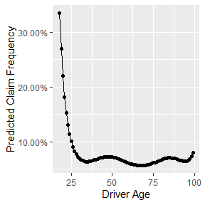

```r
library(ggplot2)
library(scales)

partial_dep = tibble(DriverAge = sort(unique(training_set$DriverAge)), pred=0)

for (row in 1:nrow(partial_dep)){
    driver_age = as.numeric(partial_dep[row, "DriverAge"])

    partial_dep[row, "pred"] = mean((predict(m11_fit,
                                             new_data = training_set
                                             %>% mutate(DriverAge = driver_age))/training_set$Exposure)$.pred)
}

ggplot(partial_dep, aes(x=DriverAge, y=pred)) +
geom_point() +
geom_line()+
scale_x_continuous(name="Driver Age")+
scale_y_continuous(name = "Predicted Claim Frequency", labels=label_percent(accuracy=0.01))
```

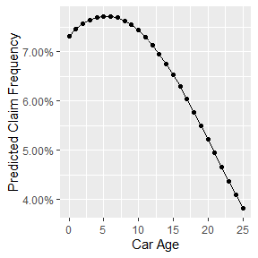

```r
partial_dep = tibble(CarAge = sort(unique(training_set$CarAge)), pred=0)

for (row in 1:nrow(partial_dep)){
    car_age = as.numeric(partial_dep[row, "CarAge"])

    partial_dep[row, "pred"] = mean((predict(m11_fit,
                                             new_data = training_set
                                             %>% mutate(CarAge = car_age))/training_set$Exposure)$.pred)
}

ggplot(partial_dep, aes(x=CarAge, y=pred)) +
geom_point() +
geom_line()+
scale_x_continuous(name="Car Age")+
scale_y_continuous(name = "Predicted Claim Frequency", labels=label_percent(accuracy=0.01))
```

# Useful links

- https://raw.githubusercontent.com/rstudio/cheatsheets/main/factors.pdf
- https://www.tidymodels.org/index.html
- https://parsnip.tidymodels.org/
- https://recipes.tidymodels.org/index.html